# Analysis of Admission Success

- Show All Code
- Hide All Code

Author

Yiming Chen, Haoqi Wang

**Goal** : The objective is to identify the variables that most closely correspond with admission success using comparative analysis and visualization tools. This could contain demographic information, extracurricular activity, or academic accomplishments, giving the committee an idea of the qualities the candidates value. Through understanding the traits of successful applicants, we aim to help prospective students tailor their application strategies to highlight their strengths in areas that matter most to the admissions committee. This could involve focusing on improving certain test scores, gaining more relevant work or volunteer experience.

### Data Cleaning

```python
import pandas as pd

df = pd.read_csv('SummerStudentAdmissions2.csv')
# Remove specific rows
cleaned_df = df[df['Gender'] != -1]
cleaned_df = cleaned_df[cleaned_df['Decision'] != 'Banana']
cleaned_df = cleaned_df[cleaned_df['WorkExp'] < 10]
cleaned_df = cleaned_df[cleaned_df['GPA'] != 6]

# Handle missing values
cleaned_df.dropna(inplace=True)

# Standardize text data, capitalize the first letter for all the state
cleaned_df['State'] = cleaned_df['State'].str.title()
```

```python
cleaned_df.info()
```

```
<class 'pandas.core.frame.DataFrame'>
Index: 80 entries, 0 to 87
Data columns (total 8 columns):
 #   Column          Non-Null Count  Dtype
---  ------          --------------  -----
 0   Decision        80 non-null     object
 1   State           80 non-null     object
 2   GPA             80 non-null     float64
 3   WorkExp         80 non-null     float64
 4   TestScore       80 non-null     float64
 5   WritingScore    80 non-null     int64
 6   Gender          80 non-null     float64
 7   VolunteerLevel  80 non-null     int64
dtypes: float64(4), int64(2), object(2)
memory usage: 5.6+ KB
```

```python
cleaned_df.head()
```

|  | Decision | State | GPA | WorkExp | TestScore | WritingScore | Gender | VolunteerLevel |
| --- | --- | --- | --- | --- | --- | --- | --- | --- |
| 0 | Admit | California | 3.90 | 6.7 | 962.0 | 100 | 1.0 | 0 |
| 1 | Admit | Florida | 3.80 | 1.4 | 969.0 | 97 | 1.0 | 4 |
| 3 | Admit | Colorado | 3.60 | 0.9 | 969.0 | 97 | 0.0 | 2 |
| 6 | Admit | California | 3.88 | 1.5 | 967.0 | 95 | 1.0 | 5 |
| 7 | Admit | California | 3.70 | 1.2 | 969.0 | 94 | 1.0 | 2 |

```python
cleaned_df.shape
```

[output not shown]

## Overview

### Plot 1: Pie Chart of Admission Percentage

This pie chart provides an overview of the distribution of admission decisions across three categories: admit, decline, and waitlist. It serves as a snapshot to understand the difficulty of gaining admission to the college and offers insights into the competitiveness of the admission process. The proportions depicted in the chart reveal that the distribution among the three categories is relatively balanced, with the “admitted” category slightly higher and the “waitlisted” category slightly lower. Specifically, around one-third of applicants successfully secure admission to the college, while approximately two-thirds are either declined or placed on the waitlist.

Understanding this distribution lays the foundation for further exploration into the main factors influencing admission decisions. By delving deeper into variables such as TestScores, GPA, WritingScores, and potentially other factors, we can elucidate the key determinants driving the admission outcomes. This detailed analysis aims to uncover patterns, and correlations that contribute to the decision-making process. Such insights can inform admission strategies and provide valuable guidance for prospective applicants aiming to navigate the admission process effectively.

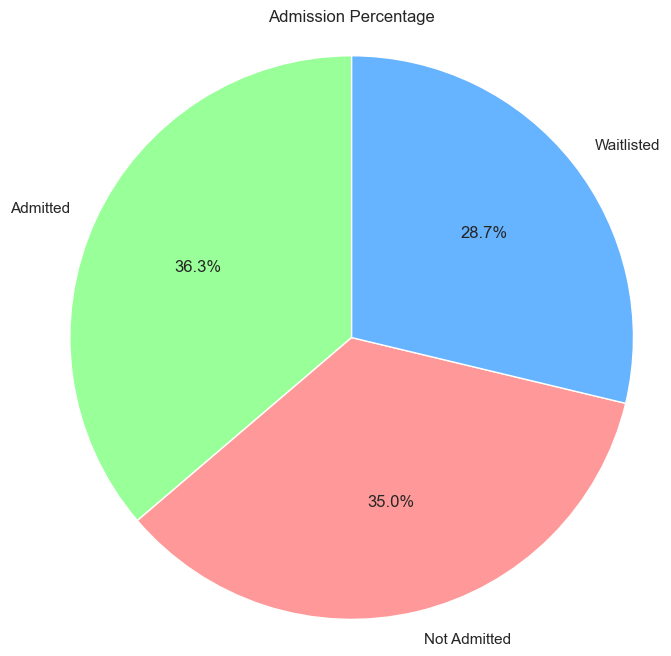

```python
import matplotlib.pyplot as plt
import seaborn as sns

admission_counts = cleaned_df['Decision'].value_counts(normalize=True) * 100

labels = ['Admitted', 'Not Admitted', 'Waitlisted']
colors = ['#99ff99', '#ff9999', '#66b3ff']


plt.figure(figsize=(8, 8))
plt.pie(admission_counts, labels=labels, colors=colors, autopct='%1.1f%%', startangle=90)
plt.title('Admission Percentage')
plt.axis('equal')

plt.show()
```

### Plot 2: Heatmap (Variables vs. Decision)

This heatmap shows the correlation among each variable, except for the “State” variable. There are two reasons that we have excluded “State”: first, it is a categorical variable, including it in a correlation analysis doesn’t make much sense in providing meaningful correlation in the context, and second, there are so many states in the “State” variable, where each state represents a separate category, potentailly could obscure any meaningful correlations among other variables. The “Decision” variable is also categorical, but it serves as our target variable. To incorporate it into the correlation analysis, each of its three categories was encoded into numerical values ranging from 0 to 2.

The heatmap reveals distinct relationships between each variable and the “Decision” variable. “TestScore” exhibits the strongest correlation, standing at 0.93, followed by “GPA” at 0.67, and “WritingScore” at 0.37. However, when variables such as “WorkExp,” “Gender,” and “VolunteerLevel” exhibit low correlation with the “Decision” variable, it suggests that these factors may not significantly influence the admission decision in this context. The heatmap indicates that admission decisions were strongly influenced by the three scores of students, namely “TestScore,” “GPA,” and “WritingScore.” These variables exhibit significant correlations with the admission decision, suggesting that they play a crucial role in determining the outcome.

Further analysis focusing on these three variables will provide valuable insights into the factors driving admission decisions. By exploring these variables in more detail, such as examining their distributions, and their relationships with each other, we can gain a deeper understanding of how they contribute to the decision-making process.

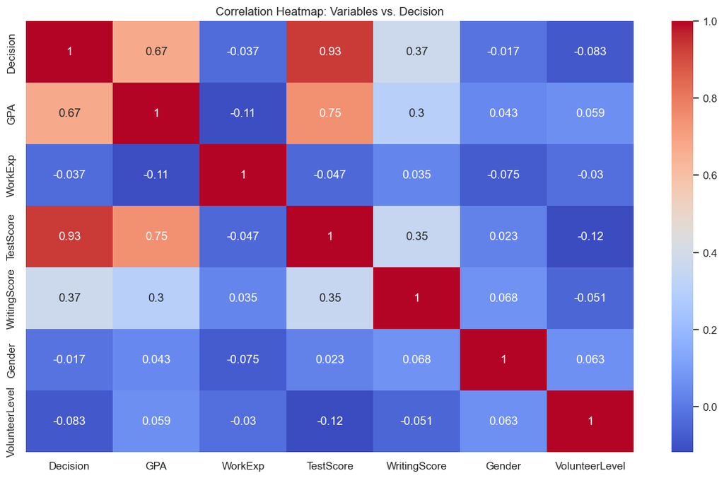

```python
# convert Decision to numerical values for heatmap
selected_df = cleaned_df.drop('State', axis=1)
selected_df['Decision'] = cleaned_df['Decision'].map({'Admit': 2, 'Waitlist': 1, 'Decline': 0})

# create a heatmap
plt.figure(figsize=(14, 8))
correlation_matrix = selected_df.corr()
sns.heatmap(correlation_matrix, annot=True, cmap='coolwarm')

plt.title('Correlation Heatmap: Variables vs. Decision')
plt.show()
```

# Academic Metrics

### Plot 3: Box Plots for GPA, Test Scores, and Writing Scores by Admission Decision

The side-by-side boxplot and the following pariplot provide a comparative view of the distributions of GPA, TestScore, and WritingScore across the three admission decision categories: admit, decline, and waitlist. They vividly illustrate the disparities in scores among students within each category. Notably, both plots underscore that admitted students generally exhibit higher scores across all three metrics compared to the declined or waitlisted students. Specifically, admitted students tend to have substantially higher GPAs, TestScores, and WritingScores, indicating a strong correlation between academic performance and admission success.

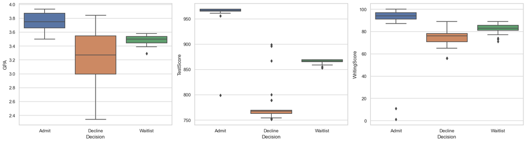

```python
fig, axes = plt.subplots(1, 3, figsize=(18, 5))
sns.boxplot(x='Decision', y='GPA', data=cleaned_df, ax=axes[0])
sns.boxplot(x='Decision', y='TestScore', data=cleaned_df, ax=axes[1])
sns.boxplot(x='Decision', y='WritingScore', data=cleaned_df, ax=axes[2])
plt.tight_layout()
plt.show()
```

### Plot 4: Pair Plot of Scores by Admission Decision

**Conclusion** :

- This pair plot suggests that GPA and TestScores are stronger predictors for admission decisions than WritingScores.
- Admission decisions show a clear trend towards higher academic scores.
- The overlap in WritingScores across different admission outcomes indicates that it might be a less decisive factor compared to the other scores.

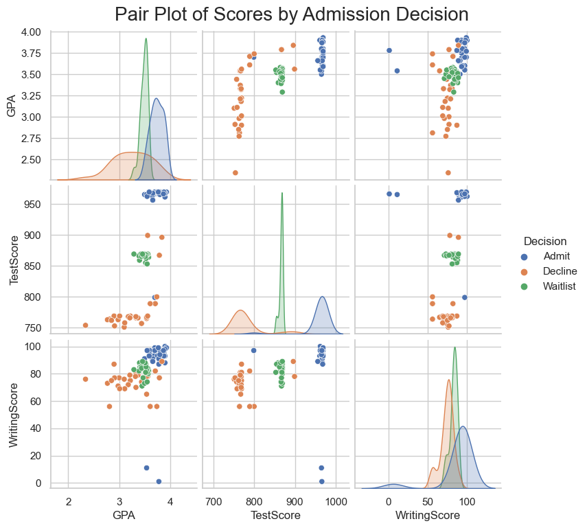

```python
sns.pairplot(cleaned_df[['GPA', 'TestScore', 'WritingScore', 'Decision']], hue='Decision')
plt.suptitle('Pair Plot of Scores by Admission Decision', size=20, y=1.02)
plt.show()
```

# Demographic Metrics

### Plot 5: Admission Decisons by Gender

- The total number of decisions (admit, decline, or waitlist) for male applicants is 45, compared to 35 for female applicants. This could suggest a larger number of male applicants or a potential difference in the way admissions decisions are distributed between genders.
- The admission rate for males is approximately 35.6% (16 out of 45), while for females, it is approximately 37.1% (13 out of 35). This shows a slightly higher admission rate for females when compared to males.
- The decline rate is almost equal for both genders, with approximately 35.6% for males and 34.3% for females. The proportion of waitlisted applicants is about 28.9% for males and 28.6% for females, which is roughly equal.

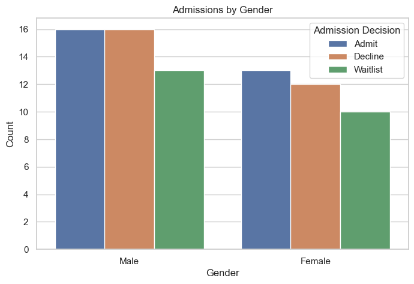

```python
# map gender values to female and male
decision_df = cleaned_df
decision_df['Gender'] = cleaned_df['Gender'].map({0:'Female', 1:'Male'})

plt.figure(figsize=(8, 5))
sns.countplot(x='Gender', hue='Decision', data=decision_df)
plt.title('Admissions by Gender')
plt.xlabel('Gender')
plt.ylabel('Count')
plt.legend(title='Admission Decision')
plt.show()
```

# Extracurricular Metrics

### Plot 6: Histogram of work experience and volunteer level

**Volunteer level** : The number of applicants across all admission decisions and volunteer levels is pretty similar, indicating that volunteer involvement are common. There is a visible increase in the number of admitted applicants with volunteer levels of 2 compared to those who are declined or waitlisted, implying that moderate levels of volunteer involvement might be positively associated with admissions. This suggests that while volunteer level may play a role in the admission decision, it is not the determining factor, given the overlap in experience between the different admission outcomes.

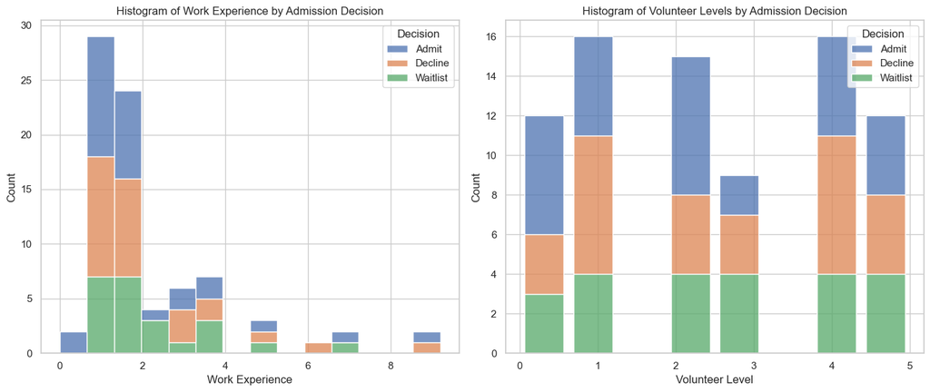

```python
plt.figure(figsize=(14, 6))
plt.subplot(1, 2, 1)
sns.histplot(data=cleaned_df, x='WorkExp', hue='Decision', multiple='stack')
plt.title('Histogram of Work Experience by Admission Decision')
plt.xlabel('Work Experience')
plt.ylabel('Count')

plt.subplot(1, 2, 2)  # 1 row, 2 cols, subplot 2
sns.histplot(data=cleaned_df, x='VolunteerLevel', hue='Decision', multiple='stack', element='bars', shrink=0.8)
plt.title('Histogram of Volunteer Levels by Admission Decision')
plt.xlabel('Volunteer Level')
plt.ylabel('Count')

# no overlap
plt.tight_layout()

# Show the plot
plt.show()
```

### Plot 7: Average work experience and volunteer level analysis

**Average Work Experience** : The data suggests that there is not a direct correlation between the amount of work experience and a positive admission decision, as those who were waitlisted or declined had marginally more work experience than those who were admitted. It’s important to note that the differences are quite small and the error bars indicate a significant overlap in the work experience across different admission outcomes, implying that work experience might not be the primary factor influencing the admission decision.

**Average Volunteer Level** : Similar to the work experience, the volunteer level data indicates that applicants with higher volunteer levels were more likely to be declined or waitlisted than admitted. This trend suggests that while volunteer work is likely valued, it is not the determining factor in the admission process. Again, the error bars suggest a significant range of volunteer levels within each admission decision category.

**Conclusion** : The analysis indicates that both work experience and volunteer levels do not have a strong positive correlation with admission success. In fact, those with higher averages in these areas were more often declined or waitlisted. This could suggest that the admissions committee values a balance between work and volunteer experience, or that other factors such as academic performance, test scores, or personal statements play a more crucial role in the decision-making process.

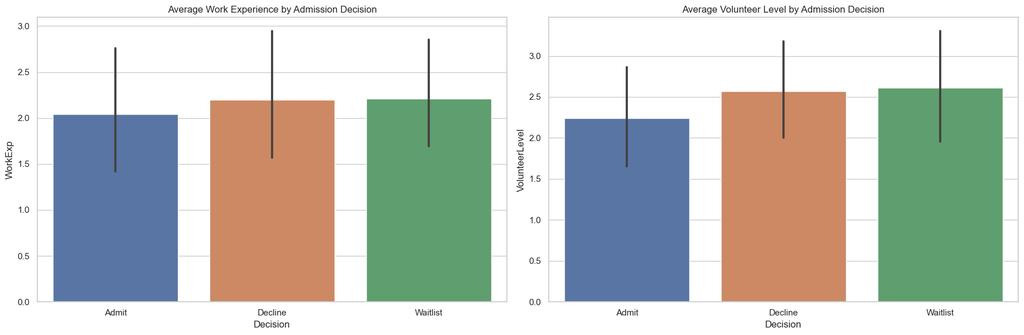

```python
import numpy as np
fig, axes = plt.subplots(1, 2, figsize=(18, 6))
sns.barplot(x='Decision', y='WorkExp', data=cleaned_df, estimator=np.mean, ax=axes[0])
axes[0].set_title('Average Work Experience by Admission Decision')

sns.barplot(x='Decision', y='VolunteerLevel', data=cleaned_df, estimator=np.mean, ax=axes[1])
axes[1].set_title('Average Volunteer Level by Admission Decision')

plt.tight_layout()
plt.show()
```

# Conclusion

**Key Findings**:

**Strategic Recommendations for Prospective Students** :

- **Focus on Academics** : Strengthen your academic credentials by excelling in standardized tests and maintaining a high GPA. These are the primary filters in the admission process.
- **Holistic Development** : Participate in extracurricular activities to show off your well-rounded personality, such as volunteer work and employment. But make sure these experiences complement rather than take away from your academic emphasis by lining them up with your career and academic goals.
- **Personalize Your Application** : Create a coherent story by combining your volunteer activity, professional experiences, and academic accomplishments in essays and personal statements. Emphasize how these experiences have equipped you for the chances and difficulties that await you in college.